# Survival Analysis Project - DSTI S19 - José Lise - November 29th 2019

# Employees turnover study using survival analysis

The goal of this project is to carry out the analysis of employee churn. We will work with a dataset available on [github](https://github.com/ludovicbenistant/Management-Analytics/blob/master/HR/HR.csv). The dataset description is also available on [Kaggle](https://www.kaggle.com/c/employee-churn-prediction/data), althouth it cannot be freely downloaded from there.

Here are the columns description:

- satisfaction_level - Employee satisfaction level
- last_evaluation - Last evaluation score
- number_project - Number of projects assigned to
- average_monthly_hour - Average monthly hours worked
- time_spend_company - Time spent at the company. Between 2 and 10.
- Work_accident - (1= Yes, 0 = No) - Whether they have had a work accident
- left - Whether or not employee left company (1 = Yes, 0 = No). This is the censoring information.
- promotion_last_5year - (1 = Yes, 0 = No) - Whether they have had a promotion in the last 5 years
- sales - Department name (not just sales)
- salary - Salary category

# Data processing

## Loading data

The following cell load the data from the csv file and assign column types numeric or character according the data stored.

```r
library(tidyverse)
raw <- read_delim("HR.csv",  delim=";", col_names=TRUE,
           col_types = cols(satisfaction_level = 'd',
                            last_evaluation = 'd',
                            number_project = 'd',
                            average_montly_hours = 'd',
                            time_spend_company = 'd',
                            Work_accident = 'd',
                            left='d',
                            promotion_last_5years = 'd',
                            sales = 'c',
                            salary = 'c'))
```

## Data transformation

In the following cell, we transform the data to assign factors to obvious categorical variables (promotion_last_5years, Work_accident, sales and salary).  
In addition, we also manage number_project as a categorical variable even it can be seen as an integer numeric variable. This decision was taken after a first exploratory analysis of the data.

```r
# Assign factor level for promotion_last_5years, Work_accident, number_project, sales and salary
# Rename sales column to department (it's less confusing)
h <- mutate(raw,
            Work_accident = factor(Work_accident, levels=c('0','1'), labels = c('no', 'yes')),
            promotion_last_5years = factor(promotion_last_5years,levels=c('0','1'),
                                           labels = c('no', 'yes')),
            number_project = factor(number_project),
            sales = factor(sales),
            salary = factor(salary))

h <- h %>% rename(dept = sales, prom_l5years = promotion_last_5years)
```

# Exploratory analysis

```r
summary(h)
```

```
##  satisfaction_level last_evaluation  number_project average_montly_hours
##  Min.   :0.0900     Min.   :0.3600   2:2388         Min.   : 96.0
##  1st Qu.:0.4400     1st Qu.:0.5600   3:4055         1st Qu.:156.0
##  Median :0.6400     Median :0.7200   4:4365         Median :200.0
##  Mean   :0.6128     Mean   :0.7161   5:2761         Mean   :201.1
##  3rd Qu.:0.8200     3rd Qu.:0.8700   6:1174         3rd Qu.:245.0
##  Max.   :1.0000     Max.   :1.0000   7: 256         Max.   :310.0
##
##  time_spend_company Work_accident      left        prom_l5years
##  Min.   : 2.000     no :12830     Min.   :0.0000   no :14680
##  1st Qu.: 3.000     yes: 2169     1st Qu.:0.0000   yes:  319
##  Median : 3.000                   Median :0.0000
##  Mean   : 3.498                   Mean   :0.2381
##  3rd Qu.: 4.000                   3rd Qu.:0.0000
##  Max.   :10.000                   Max.   :1.0000
##
##           dept         salary
##  sales      :4140   high  :1237
##  technical  :2720   low   :7316
##  support    :2229   medium:6446
##  IT         :1227
##  product_mng: 902
##  marketing  : 858
##  (Other)    :2923
```

We see that there are no missing values. The time variable that we will use for our survival analysis is **time_spend_company**. It’s in the range of 2 to 10. We have no indication of the time unit, but this looks like years if we consider the number of employees involved. The censoring variable is called **left**: it’s 1 if the employee has left the company and 0 otherwise.  
**satisfaction_level** is a decimal number in the range 0.09-1. And **last_evaluation** is a decimal number between 0.36 and 1. So the range for these 2 continuous variables are different as the satisfaction can be close to zero unlike the last_evaluation.  
**number_project** is an integer number in the range 2 to 7 managed as a categorical variable.  
**average_montly_hours** is an integer number in the range 96 to 310. There are 2 binaries categorical variables: **Work_accident** and **prom_l5years**. And the last 2 variables **department** and **salary** are also categorical variables but with at least 3 levels.

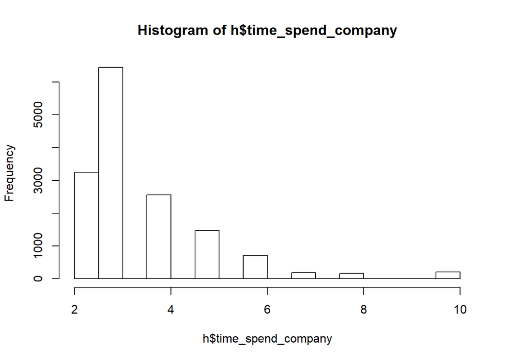

```r
hist(h$time_spend_company)
```

We see that employees start leaving the company after 2 years. The peak duration is 3 years. The number of employees leaving the company decrease from 3 years to 6 years. And from 6 years to 10 years there is almost no change.

Check how many employees left the company.

```r
table(h$left)
```

```
##
##     0     1
## 11428  3571
```

```r
prop.table(table(h$left))
```

```
##
##         0         1
## 0.7619175 0.2380825
```

## Satisfaction level, Last evaluation and Average monthly hours

Global histograms

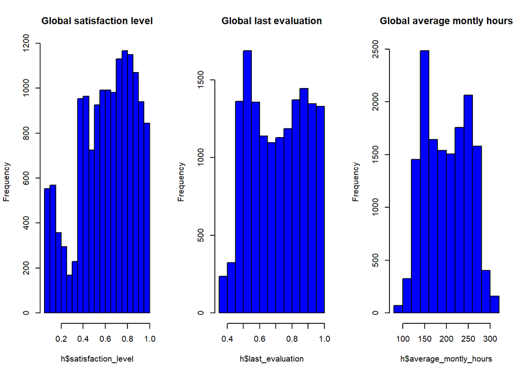

```r
par(mfrow=c(1,3))
hist(h$satisfaction_level, col = 'blue', main="Global satisfaction level")
hist(h$last_evaluation, col = 'blue', main="Global last evaluation")
hist(h$average_montly_hours, col = 'blue', main="Global average montly hours")
```

For the employees who left.

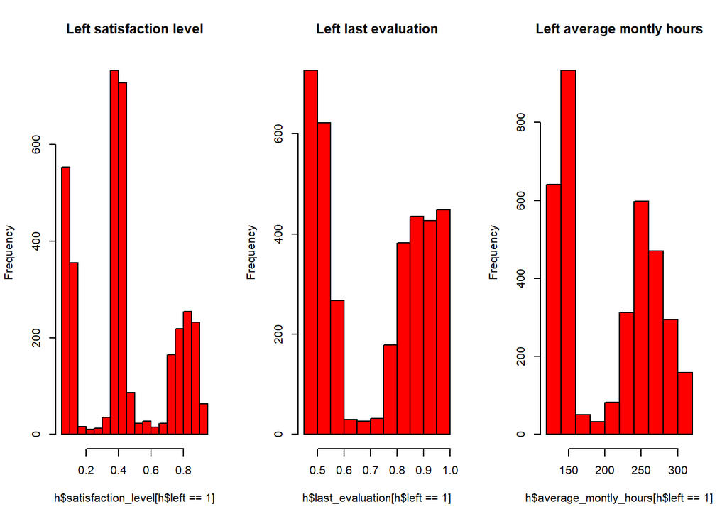

```r
par(mfrow=c(1,3))
hist(h$satisfaction_level[h$left == 1], col='red', main='Left satisfaction level')
hist(h$last_evaluation[h$left == 1], col='red', main='Left last evaluation')
hist(h$average_montly_hours[h$left == 1], col='red', main='Left average montly hours')
```

## Work accident and promotion

Barplots

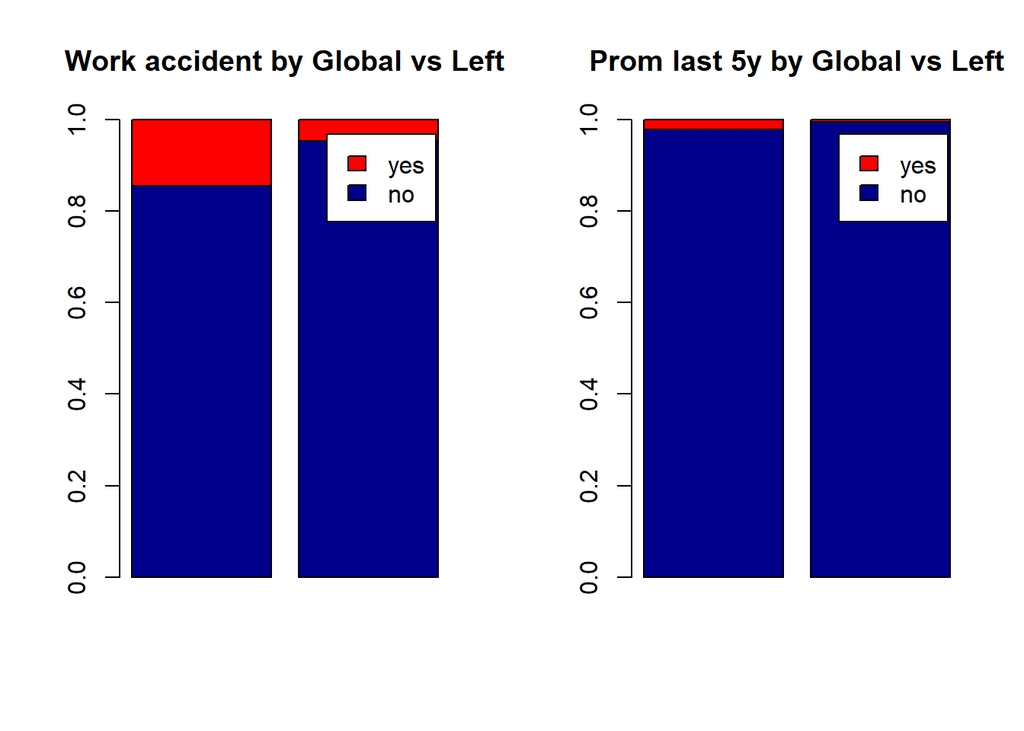

```r
par(mfrow=c(1,2))
counts.work <-  cbind(prop.table(table(h$Work_accident)), prop.table(table(h$Work_accident[h$left == 1])))
counts.prom <-  cbind(prop.table(table(h$prom_l5years)), prop.table(table(h$prom_l5years[h$left == 1])))

barplot(counts.work, main="Work accident by Global vs Left",
       col=c("darkblue","red"),legend = rownames(counts.work) )
barplot(counts.prom, main="Prom last 5y by Global vs Left",
       col=c("darkblue","red"),legend = rownames(counts.prom) )
```

The proportion of work accident is lower in the population that left. And the proportion of promotion in the last 5 years is also lower for the employees that left.

## Department, salary and number of projects

Global barplots

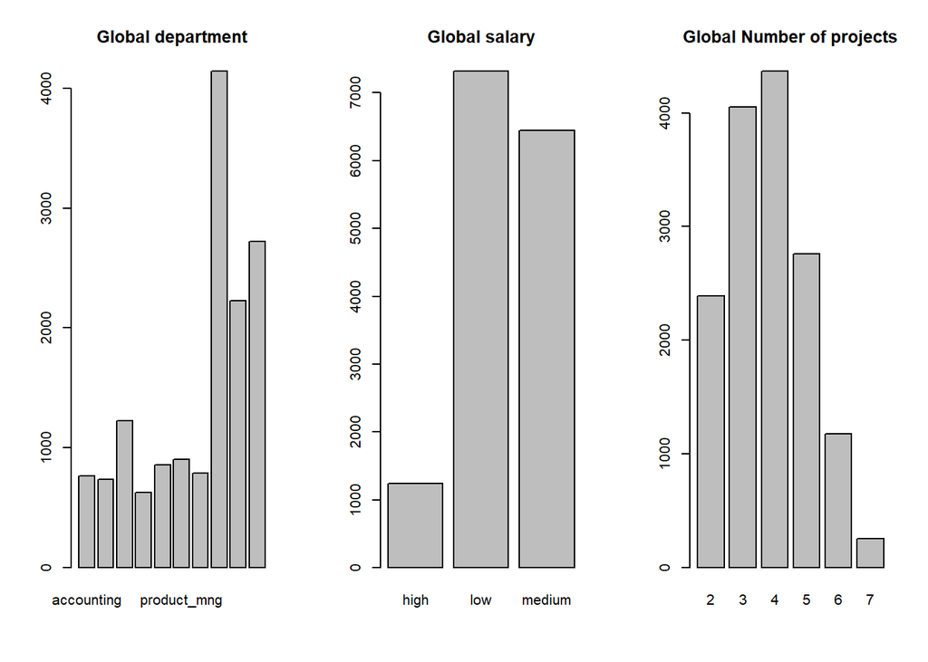

```r
par(mfrow=c(1,3))
barplot(table(h$dept) , main="Global department")
barplot(table(h$salary), main="Global salary")
barplot(table(h$number_project), main="Global Number of projects")
```

Left barplots

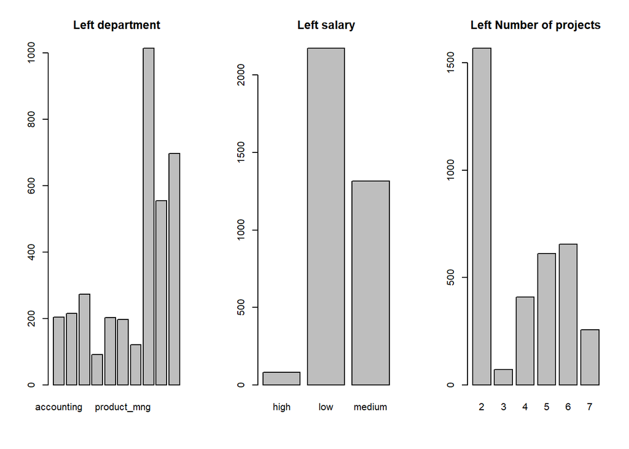

```r
par(mfrow=c(1,3))
barplot(table(h$dept[h$left == 1]), main="Left department")
barplot(table(h$salary[h$left == 1]), main="Left salary")
barplot(table(h$number_project[h$left == 1]), main="Left Number of projects")
```

From the plot above, we can already think that there is a higher risk (of leaving company) for employees with low salaries. We also notice a very small percentage of employees leaving the company while working on 3 projects.

# Kaplan-Meier estimator

As we have a time variable (**time_spend_company**) and a censoring variable (**left**), we can use Kaplan-Meier estimator to carry out the survival analysis of the employees turnover. We draw below the Kaplan-Meier survival curve using the R Survival package.

```r
library(survival)
St <- survfit(Surv(time_spend_company,left) ~ 1, data = h)
St
```

```
## Call: survfit(formula = Surv(time_spend_company, left) ~ 1, data = h)
##
##       n  events  median 0.95LCL 0.95UCL
##   14999    3571       6       5       6
```

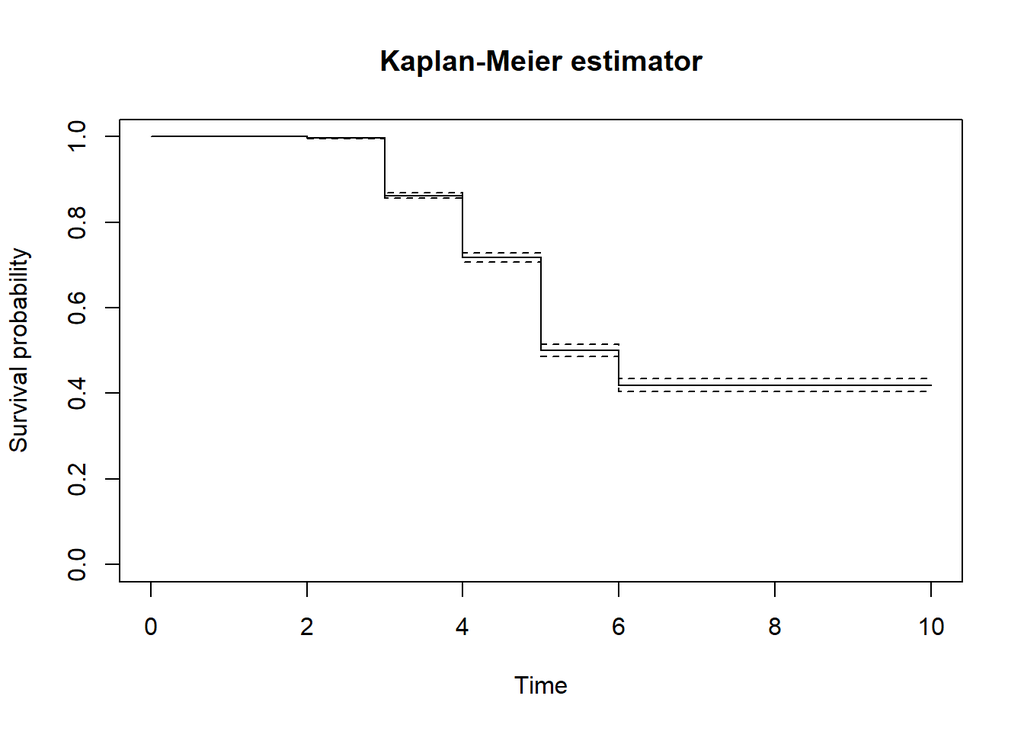

```r
plot(St, main="Kaplan-Meier estimator", xlab="Time", ylab="Survival probability")
```

The median value returned by the survfit function is 6 years. Therefore the average lifetime at the company for an employee is 6 years. The confidence interval for the median is (5,6). We also notice that the survival probability is constant after 6 years.

Survival curve by salary

```r
Sts <- survfit(Surv(time_spend_company,left) ~ salary, data = h)
Sts
```

```
## Call: survfit(formula = Surv(time_spend_company, left) ~ salary, data = h)
##
##                  n events median 0.95LCL 0.95UCL
## salary=high   1237     82     NA      NA      NA
## salary=low    7316   2172      5       5       5
## salary=medium 6446   1317      6       6      NA
```

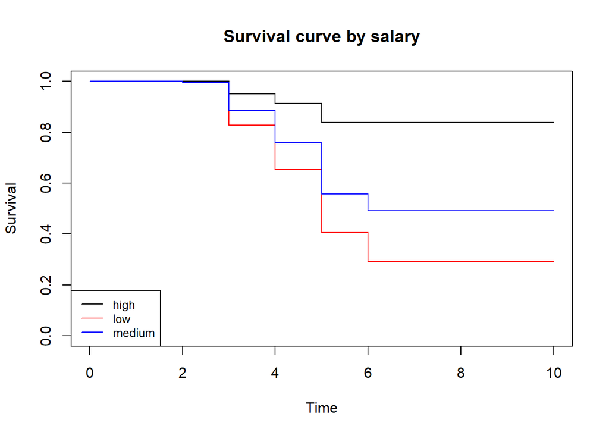

```r
plot(Sts, col=c('black','red','blue'),main="Survival curve by salary", xlab="Time", ylab="Survival")
legend("bottomleft", legend=levels(h$salary),
       col=c("black", "red", "blue"), lty=1, cex=0.8)
```

We see that the median for salary=high is undefined, because for this category the survival function is always above 0.5. The group with higher risk is salary=low group. The median for this group is 5 years, whereas it’s 6 years for the medium group.

## Comparing groups

We will compare the groups for categorical varaiables using the log rank test: Work_accident, promotion_last_5years, number_project, department, and salary.

```r
test_variable <- function(var_name) {
  h$x <- h[[ var_name ]]
  survdiff(Surv(time_spend_company,left) ~ x, data = h)
}

logrank_tests <-
  tibble(variable = c("Work_accident", "prom_l5years","number_project", "dept", "salary")) %>%
  mutate(obj = map(variable, test_variable),
         tab = map(obj, broom::glance)) %>%
  unnest(tab)
logrank_tests
```

| variable | obj | statistic | df | p.value |
| --- | --- | --- | --- | --- |
| Work_accident |  | 315.12459 | 1 | 0 |
| prom_l5years |  | 84.74424 | 1 | 0 |
| number_project |  | 5650.61139 | 5 | 0 |
| dept |  | 133.29491 | 9 | 0 |
| salary |  | 398.68306 | 2 | 0 |

```r
#survdiff(Surv(time_spend_company,left) ~ salary, data = h)
```

The table above lists the p-values for the log-rank test for the 5 selected features. And they all are zero.Therefore we reject the null hypothesis for all the variables and there is a significant difference between the groups inside each categorical variable.

# Data Modeling and Machine Learning

## Split the data randomly into a training and a testing set

Reshape the data for the modeling section

```r
hm <- h
hm <- select(hm, -c(time_spend_company, left))
summary(hm)
```

```
##  satisfaction_level last_evaluation  number_project average_montly_hours
##  Min.   :0.0900     Min.   :0.3600   2:2388         Min.   : 96.0
##  1st Qu.:0.4400     1st Qu.:0.5600   3:4055         1st Qu.:156.0
##  Median :0.6400     Median :0.7200   4:4365         Median :200.0
##  Mean   :0.6128     Mean   :0.7161   5:2761         Mean   :201.1
##  3rd Qu.:0.8200     3rd Qu.:0.8700   6:1174         3rd Qu.:245.0
##  Max.   :1.0000     Max.   :1.0000   7: 256         Max.   :310.0
##
##  Work_accident prom_l5years          dept         salary
##  no :12830     no :14680    sales      :4140   high  :1237
##  yes: 2169     yes:  319    technical  :2720   low   :7316
##                             support    :2229   medium:6446
##                             IT         :1227
##                             product_mng: 902
##                             marketing  : 858
##                             (Other)    :2923
```

```r
y <- Surv(h$time_spend_company, h$left)
```

## Creating Training and Testing sets

```r
set.seed(1234) # >To make the results replicable
i.training <- sample.int(nrow(hm), size = 10000, replace = FALSE)
i.testing <- setdiff(seq_len(nrow(hm)), i.training)

h.training <- hm[i.training,, drop = FALSE]
y.training <- y[i.training,, drop = FALSE]

h.testing <- hm[i.testing,, drop = FALSE]
y.testing <- y[i.testing,, drop = FALSE]
```

## Cox regression

We will apply the Cox Hazard Ratio model using all the available covariates.

```r
fit <- coxph(y.training ~ ., data = h.training)
summary(fit)
```

```
## Call:
## coxph(formula = y.training ~ ., data = h.training)
##
##   n= 10000, number of events= 2349
##
##                            coef  exp(coef)   se(coef)       z Pr(>|z|)
## satisfaction_level   -1.3758537  0.2526238  0.0972747 -14.144  < 2e-16 ***
## last_evaluation       0.3416539  1.4072732  0.1390696   2.457 0.014022 *
## number_project3      -3.8966877  0.0203091  0.1536340 -25.363  < 2e-16 ***
## number_project4      -2.4783931  0.0838779  0.0722274 -34.314  < 2e-16 ***
## number_project5      -1.9552822  0.1415245  0.0667471 -29.294  < 2e-16 ***
## number_project6      -1.5904266  0.2038386  0.0731070 -21.755  < 2e-16 ***
## number_project7      -1.1724280  0.3096143  0.1036601 -11.310  < 2e-16 ***
## average_montly_hours  0.0017139  1.0017154  0.0004609   3.718 0.000200 ***
## Work_accidentyes     -1.0658406  0.3444382  0.0948818 -11.233  < 2e-16 ***
## prom_l5yearsyes      -1.2623686  0.2829830  0.2931334  -4.306 1.66e-05 ***
## depthr                0.1223856  1.1301898  0.1192012   1.027 0.304555
## deptIT               -0.2230508  0.8000742  0.1117225  -1.996 0.045883 *
## deptmanagement       -0.3404954  0.7114178  0.1617162  -2.106 0.035247 *
## deptmarketing        -0.0874729  0.9162437  0.1174796  -0.745 0.456526
## deptproduct_mng      -0.1320352  0.8763101  0.1214769  -1.087 0.277074
## deptRandD            -0.4944834  0.6098859  0.1411754  -3.503 0.000461 ***
## deptsales            -0.1284146  0.8794887  0.0915818  -1.402 0.160860
## deptsupport           0.0458381  1.0469049  0.0981150   0.467 0.640366
## depttechnical        -0.0603481  0.9414368  0.0956597  -0.631 0.528131
## salarylow             1.2179529  3.3802610  0.1404599   8.671  < 2e-16 ***
## salarymedium          0.8794271  2.4095189  0.1415882   6.211 5.26e-10 ***
## ---
## Signif. codes:  0 '***' 0.001 '**' 0.01 '*' 0.05 '.' 0.1 ' ' 1
##
##                      exp(coef) exp(-coef) lower .95 upper .95
## satisfaction_level     0.25262     3.9585   0.20877   0.30569
## last_evaluation        1.40727     0.7106   1.07152   1.84822
## number_project3        0.02031    49.2391   0.01503   0.02745
## number_project4        0.08388    11.9221   0.07281   0.09663
## number_project5        0.14152     7.0659   0.12417   0.16130
## number_project6        0.20384     4.9058   0.17663   0.23524
## number_project7        0.30961     3.2298   0.25269   0.37936
## average_montly_hours   1.00172     0.9983   1.00081   1.00262
## Work_accidentyes       0.34444     2.9033   0.28599   0.41483
## prom_l5yearsyes        0.28298     3.5338   0.15931   0.50266
## depthr                 1.13019     0.8848   0.89472   1.42763
## deptIT                 0.80007     1.2499   0.64273   0.99593
## deptmanagement         0.71142     1.4056   0.51817   0.97674
## deptmarketing          0.91624     1.0914   0.72780   1.15348
## deptproduct_mng        0.87631     1.1411   0.69065   1.11188
## deptRandD              0.60989     1.6397   0.46247   0.80430
## deptsales              0.87949     1.1370   0.73498   1.05241
## deptsupport            1.04690     0.9552   0.86376   1.26889
## depttechnical          0.94144     1.0622   0.78049   1.13558
## salarylow              3.38026     0.2958   2.56679   4.45154
## salarymedium           2.40952     0.4150   1.82562   3.18017
##
## Concordance= 0.911  (se = 0.004 )
## Likelihood ratio test= 3706  on 21 df,   p=<2e-16
## Wald test            = 2879  on 21 df,   p=<2e-16
## Score (logrank) test = 4669  on 21 df,   p=<2e-16
```

Cox Hazard Ratio Analysis:  
Most of the hazard ratio coefficients are significants (P-values very small or less than 5%) except for some of the department levels.

The variable with the more higher coefficient is number_project3. And this coefficient is negative and therefore reduce the risk: Working on 3 projects reduce the risk by a factor 49 CI(36, 66) compared to working on 2 projects (which is the reference level). And we see also that working on 4 projects decrease the risk by a factor 11.9 CI( 10.3, 13.7)compared to working on 2 projects. And the risk is decreased by a factor 7 CI(6.2,8), 4.9 CI(4.2, 5.6) and 3.2 CI(2.6, 3.9) for respectively 5, 6 and 7 projects.

The next most higher coefficient is the satisfaction level: An increase by one unit (which is the full range) reduces the risk by a factor 3.95 CI(3.3, 4.8).

Then in the coefficient range we have the salary impact: risk is increased by a factor 3.38 CI(2.6, 4.4) from Salary_high to Salary_low, and by a factor 2.4 CI(1.8, 3.2) from salary_high to salary_medium.

Then we have in terms of importance level: prom_l5yearsyes. A promotion in the last 5 years reduce the risk by a factor 3.5 CI (2,6.3) compared to no promotion.

Next coefficient is Work_accidentyes: The risk is reduced by a factor 2.9 CI( 2.4,3.5) compared to Work_accidentNo. This is counter intuitive, but looking at the exploratory plot, the proportion of Work_accidentyes is lower for people who left.

There is not much difference in hazard ratio coefficient for the department variable. The higher evidence, is that risk for R&D departent compared to accounting is lower by a factor 1.6 CI(1.2, 2.2).

## Model 1 - AIC Step

In this section we will use the step function to select the model with the lower AIC.

```r
fit.aic <- step(fit)
```

```
## Start:  AIC=34880.95
## y.training ~ satisfaction_level + last_evaluation + number_project +
##     average_montly_hours + Work_accident + prom_l5years + dept +
##     salary
##
##                        Df   AIC
## <none>                    34881
## - last_evaluation       1 34885
## - average_montly_hours  1 34893
## - dept                  9 34899
## - prom_l5years          1 34907
## - salary                2 35021
## - Work_accident         1 35052
## - satisfaction_level    1 35084
## - number_project        5 37128
```

```r
summary(fit.aic)
```

```
## Call:
## coxph(formula = y.training ~ satisfaction_level + last_evaluation +
##     number_project + average_montly_hours + Work_accident + prom_l5years +
##     dept + salary, data = h.training)
##
##   n= 10000, number of events= 2349
##
##                            coef  exp(coef)   se(coef)       z Pr(>|z|)
## satisfaction_level   -1.3758537  0.2526238  0.0972747 -14.144  < 2e-16 ***
## last_evaluation       0.3416539  1.4072732  0.1390696   2.457 0.014022 *
## number_project3      -3.8966877  0.0203091  0.1536340 -25.363  < 2e-16 ***
## number_project4      -2.4783931  0.0838779  0.0722274 -34.314  < 2e-16 ***
## number_project5      -1.9552822  0.1415245  0.0667471 -29.294  < 2e-16 ***
## number_project6      -1.5904266  0.2038386  0.0731070 -21.755  < 2e-16 ***
## number_project7      -1.1724280  0.3096143  0.1036601 -11.310  < 2e-16 ***
## average_montly_hours  0.0017139  1.0017154  0.0004609   3.718 0.000200 ***
## Work_accidentyes     -1.0658406  0.3444382  0.0948818 -11.233  < 2e-16 ***
## prom_l5yearsyes      -1.2623686  0.2829830  0.2931334  -4.306 1.66e-05 ***
## depthr                0.1223856  1.1301898  0.1192012   1.027 0.304555
## deptIT               -0.2230508  0.8000742  0.1117225  -1.996 0.045883 *
## deptmanagement       -0.3404954  0.7114178  0.1617162  -2.106 0.035247 *
## deptmarketing        -0.0874729  0.9162437  0.1174796  -0.745 0.456526
## deptproduct_mng      -0.1320352  0.8763101  0.1214769  -1.087 0.277074
## deptRandD            -0.4944834  0.6098859  0.1411754  -3.503 0.000461 ***
## deptsales            -0.1284146  0.8794887  0.0915818  -1.402 0.160860
## deptsupport           0.0458381  1.0469049  0.0981150   0.467 0.640366
## depttechnical        -0.0603481  0.9414368  0.0956597  -0.631 0.528131
## salarylow             1.2179529  3.3802610  0.1404599   8.671  < 2e-16 ***
## salarymedium          0.8794271  2.4095189  0.1415882   6.211 5.26e-10 ***
## ---
## Signif. codes:  0 '***' 0.001 '**' 0.01 '*' 0.05 '.' 0.1 ' ' 1
##
##                      exp(coef) exp(-coef) lower .95 upper .95
## satisfaction_level     0.25262     3.9585   0.20877   0.30569
## last_evaluation        1.40727     0.7106   1.07152   1.84822
## number_project3        0.02031    49.2391   0.01503   0.02745
## number_project4        0.08388    11.9221   0.07281   0.09663
## number_project5        0.14152     7.0659   0.12417   0.16130
## number_project6        0.20384     4.9058   0.17663   0.23524
## number_project7        0.30961     3.2298   0.25269   0.37936
## average_montly_hours   1.00172     0.9983   1.00081   1.00262
## Work_accidentyes       0.34444     2.9033   0.28599   0.41483
## prom_l5yearsyes        0.28298     3.5338   0.15931   0.50266
## depthr                 1.13019     0.8848   0.89472   1.42763
## deptIT                 0.80007     1.2499   0.64273   0.99593
## deptmanagement         0.71142     1.4056   0.51817   0.97674
## deptmarketing          0.91624     1.0914   0.72780   1.15348
## deptproduct_mng        0.87631     1.1411   0.69065   1.11188
## deptRandD              0.60989     1.6397   0.46247   0.80430
## deptsales              0.87949     1.1370   0.73498   1.05241
## deptsupport            1.04690     0.9552   0.86376   1.26889
## depttechnical          0.94144     1.0622   0.78049   1.13558
## salarylow              3.38026     0.2958   2.56679   4.45154
## salarymedium           2.40952     0.4150   1.82562   3.18017
##
## Concordance= 0.911  (se = 0.004 )
## Likelihood ratio test= 3706  on 21 df,   p=<2e-16
## Wald test            = 2879  on 21 df,   p=<2e-16
## Score (logrank) test = 4669  on 21 df,   p=<2e-16
```

```r
b.aic <- coef(fit.aic)
```

The AIC step function finds that the best model (lower AIC) is the model with all the variables.

The Concordance is 0.911 and therefore is quite high.

### Models testing: AIC

In the following section, we will test the model selected by AIC. We apply the model previously fitted to the testing dataset, to get the scoreAIC.testing.

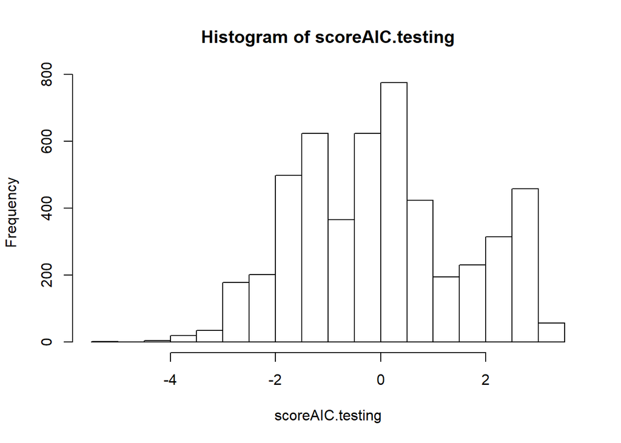

```r
scoreAIC.testing <- predict(fit.aic, newdata = h.testing)
hist(scoreAIC.testing)
```

```r
summary(coxph(y.testing ~ scoreAIC.testing))
```

```
## Call:
## coxph(formula = y.testing ~ scoreAIC.testing)
##
##   n= 4999, number of events= 1222
##
##                     coef exp(coef) se(coef)     z Pr(>|z|)
## scoreAIC.testing 1.04105   2.83218  0.02675 38.91   <2e-16 ***
## ---
## Signif. codes:  0 '***' 0.001 '**' 0.01 '*' 0.05 '.' 0.1 ' ' 1
##
##                  exp(coef) exp(-coef) lower .95 upper .95
## scoreAIC.testing     2.832     0.3531     2.687     2.985
##
## Concordance= 0.913  (se = 0.005 )
## Likelihood ratio test= 2002  on 1 df,   p=<2e-16
## Wald test            = 1514  on 1 df,   p=<2e-16
## Score (logrank) test = 1816  on 1 df,   p=<2e-16
```

Coefficient is positive(1.04) therefore higher score means higher risk. The hazard ratio is 2.83 with confidence interval (2.69, 2.98). And as the p-value is small, this means this coefficient is significant.

We also notice that the concordance is very high: 0.913 with a standard error of 0.005. This model score is very good, but we use all the features provided.

Check the model AUC for time=4

```r
library(survivalROC)
ROC <- survivalROC(Stime = y.testing[, 1],
                   status = y.testing[, 2],
                   marker = scoreAIC.testing,
                   cut.values = quantile(scoreAIC.testing, prob = 0:100/100),
                   predict.time = 4,
                   method = "KM")
ROC$AUC
```

```
## [1] 0.8230943
```

The AUC for time=4 is 0.82 and therefore quite high.

Let’s see if we can reduce the number of features while keeping the same kind of performance.

## model 2. elastic net

plotting

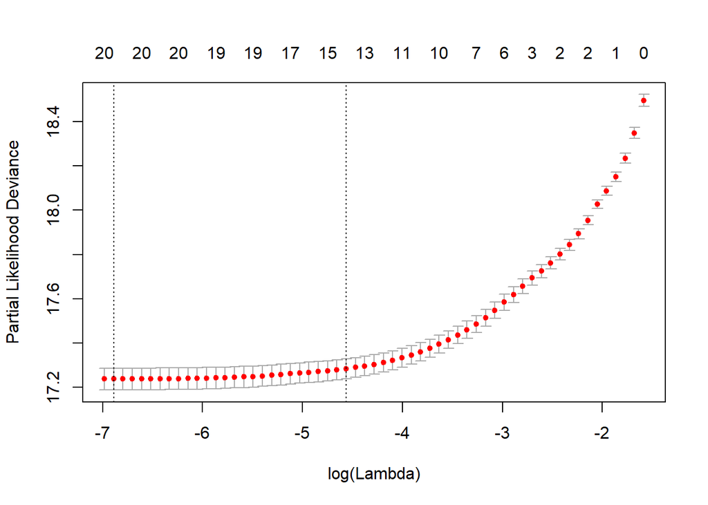

```r
plot(fit.cv10)
```

[output not shown]

We select Lambda.1se the less conservative lambda, which is also the lambda with the lower number of coefficients.

```r
b <- coef(fit.cv10, s = "lambda.1se")
sum(b != 0)
```

```
## [1] 14
```

```r
b.enet <- b[b != 0]
```

Lambda.1se has 14 non null coefficients.

```r
round(b[abs(b) > 1e-3 ], digits = 3)
```

```
##  [1] -1.105  0.219  1.780 -1.122 -0.270  0.347  0.685  0.002 -0.642 -0.487
## [11]  0.009 -0.215 -0.075  0.269
```

### Model testing: elastic net

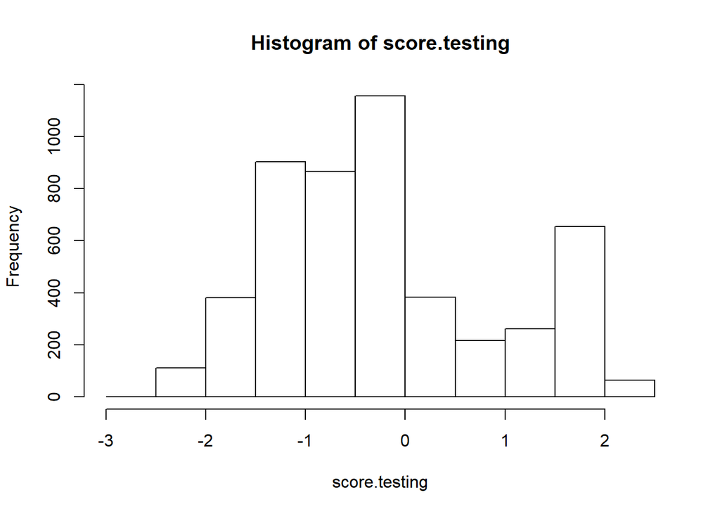

```r
X.testing <- model.matrix( ~ . -1 , data = h.testing)
score.testing <- predict(fit.cv10, newx = X.testing, s = "lambda.1se")
hist(score.testing)
```

Higher score means higher risk and then lower survival. The score is in the range (-3, 2.5).

y.testing is a censored variable and score.testing is assumed to be a continuous predictor of this variable. A continuous predictor vs a right-censored time-to-failure outcome: we can use Cox regression.

```r
summary(coxph(y.testing ~ score.testing))
```

```
## Call:
## coxph(formula = y.testing ~ score.testing)
##
##   n= 4999, number of events= 1222
##
##                  coef exp(coef) se(coef)     z Pr(>|z|)
## score.testing 1.25473   3.50690  0.03119 40.23   <2e-16 ***
## ---
## Signif. codes:  0 '***' 0.001 '**' 0.01 '*' 0.05 '.' 0.1 ' ' 1
##
##               exp(coef) exp(-coef) lower .95 upper .95
## score.testing     3.507     0.2852     3.299     3.728
##
## Concordance= 0.913  (se = 0.006 )
## Likelihood ratio test= 1894  on 1 df,   p=<2e-16
## Wald test            = 1618  on 1 df,   p=<2e-16
## Score (logrank) test = 2049  on 1 df,   p=<2e-16
```

And the concordance is the same as with the previous model: 0.913 with a slightly higher SE of 0.006.

AUC index at 4 years

```r
library(survivalROC)
ROC <- survivalROC(Stime = y.testing[, 1],
                   status = y.testing[, 2],
                   marker = score.testing,
                   cut.values = quantile(score.testing, prob = 0:100/100),
                   predict.time = 4,
                   method = "KM")
ROC$AUC
```

```
## [1] 0.8186644
```

The AUC at 4 years is also 0.82 as for AIC selected model.

# Conclusion

We analyzed the employees turnover of a company using survival analysis modeling over a period of 10 time unit that we assumed to be years. After an exploratory analysis, we computed the Kaplan-Meier estimator for survival probability. Then we identified that the median survival at the company is 6 years: the expected time spent at the company is 6 years. Then we used the log rank test to check if the levels in the 5 categorical features have an impact on the survival. The p-value for the log rank test is zero for all the categorical variables. Therefore for all the categorical variables we reject the null hypothesis that there is no difference between the categories defined by these variables.

We then carried out model selection using AIC and GLMNET. AIC returned the full model as the best model and GLMNET returned a model with 14 coefficients out of 21.

We then did some predictions using the test dataset and use cox regression again to assess the accuracy of the models. Both model gave a very high concordance index of 0.913 and AUC at 4 years of 0.82.